# hwk_12

Holden Jones

2025-05-12

```r
library(tidyverse)
library(lme4)
```

```r
library(sjPlot)
library(MuMIn)
library(DHARMa)
library(glmmTMB)
library(lmerTest)
island <- read_csv('data/cabral_island_data.csv') %>%
  select(!'...1')
```

```
## ──────────────────────────────────────────────────────── Delimiter: "," chr
## (1): Archipelago dbl (5): ...1, Species, Area, Elev, Temp
```

```r
arch <- read_csv('data/cabral_arch_data.csv') %>%
  select(!'...1') %>%
  slice(1:23)
```

```
## ──────────────────────────────────────────────────────── Delimiter: "," chr
## (1): Archipelago dbl (4): ...1, number.islands, distance, age
```

data naturally organized into groups (archipelagoes), account for this structure - non-independence in the model - need archipelago random effect to avoid pseudoreplicating predictors defined at archipelago scale

Make a model with species richness as the response, and with a random effect for Archipelago. Species richness could be modeled as discrete count data (e.g., a negative binomial distribution), but we’ll finish covering GLMMs later; for now you can use log(Richness+1) to get a pretty normal looking response.

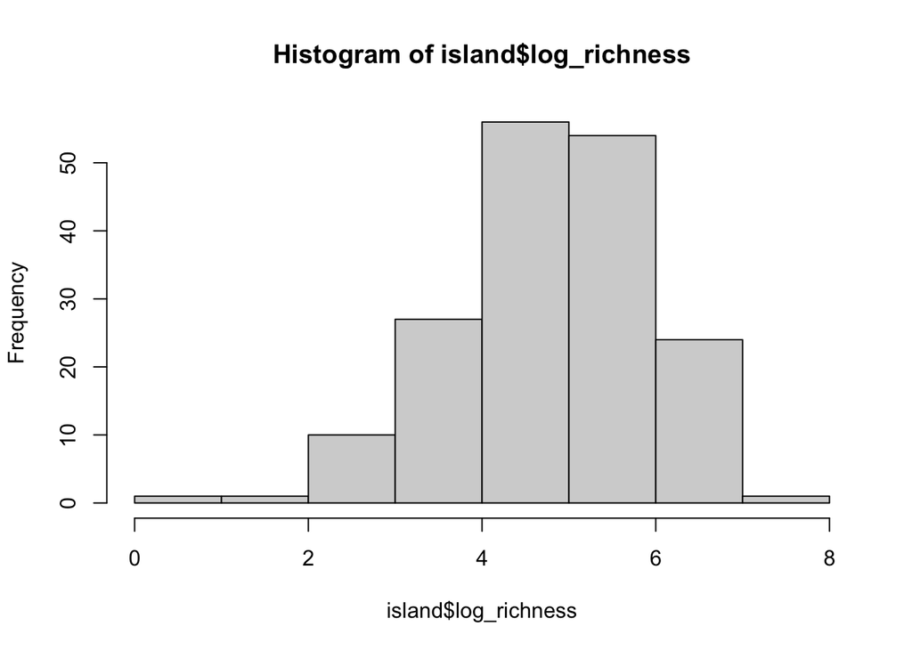

```r
island$log_richness <- log(island$Species + 1)

hist(island$log_richness) # great, looks normal
```

```r
mod_rich_arch <- lmer(log_richness ~ (1|Archipelago), data = island)
summary(mod_rich_arch)
```

```
## Linear mixed model fit by REML. t-tests use Satterthwaite's method [
## lmerModLmerTest]
## Formula: log_richness ~ (1 | Archipelago)
##    Data: island
##
## REML criterion at convergence: 501.2
##
## Scaled residuals:
##     Min      1Q  Median      3Q     Max
## -5.1507 -0.5357  0.0796  0.5790  1.9455
##
## Random effects:
##  Groups      Name        Variance Std.Dev.
##  Archipelago (Intercept) 0.6408   0.8005
##  Residual                0.8243   0.9079
## Number of obs: 174, groups:  Archipelago, 23
##
## Fixed effects:
##             Estimate Std. Error      df t value Pr(>|t|)
## (Intercept)   4.7685     0.1865 18.9104   25.57 3.94e-16 ***
## ---
## Signif. codes:  0 '***' 0.001 '**' 0.01 '*' 0.05 '.' 0.1 ' ' 1
```

```r
ranef(mod_rich_arch)
```

```
## $Archipelago
##                             (Intercept)
## Aldabra                      0.28121897
## Azores                       0.36773210
## Balearic Islands             1.18183176
## Canaries                     1.45904002
## Cape Verde                  -0.22621387
## Cook islands                -0.22591288
## Dutch Caribbean              0.91678059
## Galapagos                    0.09980580
## Hawaii                      -0.09227461
## Iles Crozet                 -1.16604580
## Inner Seychelles             0.06058546
## Juan Fernandez               0.06298814
## Kuril Islands                0.12453644
## Madeira                      0.74721555
## Marianas                    -0.11819580
## Marquesas                    0.10645794
## North. Cal. Channel Islands  0.67822271
## Phoenix Islands             -1.35368520
## Pitcairn Islands            -0.94759395
## Prince Edward Islands       -0.90859247
## Revillagigedo Islands       -0.71128117
## Society Islands             -0.02387580
## Tristan da Cunha            -0.31274390
##
## with conditional variances for "Archipelago"
```

What proportion of the variation in species richness occurs at the archipelago scale, and what proportion occurs within archipelagoes? Which archipelagoes are particularly diverse, and which are depauperate?  
- 0.64 variance at archipelagoe level - 0.82 variance within archipelagoes - particularly diverse; Canaries, Balearic - particularly depauperate; Phoenix, Iles Crozet

Now let’s think about the six predictors. Make some exploratory plots of the effect of each variable on richness, plotted at the appropriate scale. You’ll need to merge the datasets. Think about which predictors might need to be transformed for use in a linear model.

merge df

```r
df <- left_join(arch, island, by = 'Archipelago')
```

exploratory plots for each var against log_richness

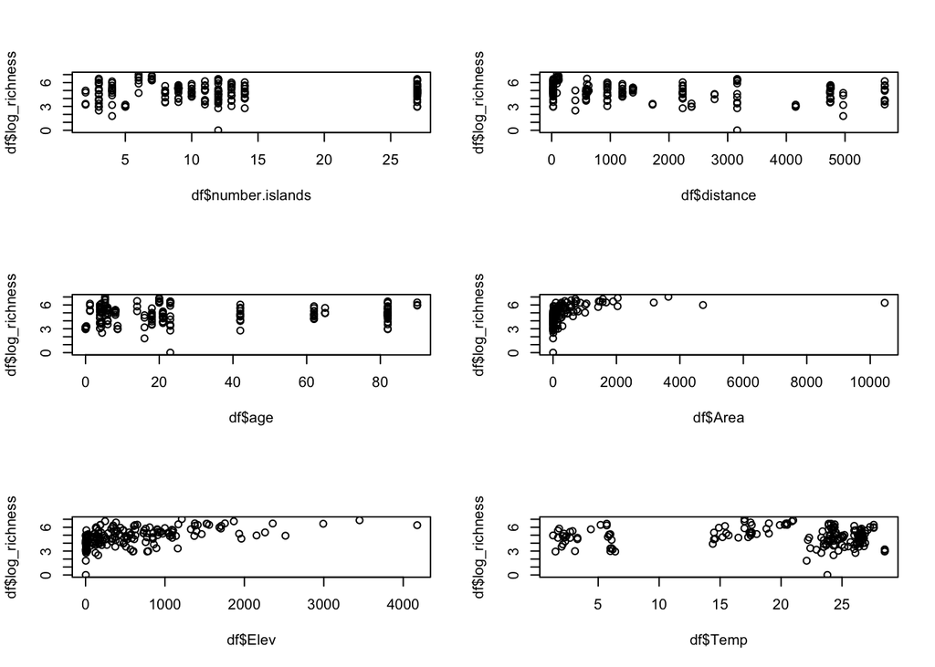

```r
par(mfrow = c(3, 2))
plot(df$number.islands, df$log_richness) # maybe transform
plot(df$distance, df$log_richness)
plot(df$age, df$log_richness)
plot(df$Area, df$log_richness) # transform
plot(df$Elev, df$log_richness) # transform
plot(df$Temp, df$log_richness)
```

transform Elev and Area - huge range for these vars w/ big outliers - also can transform number.islands

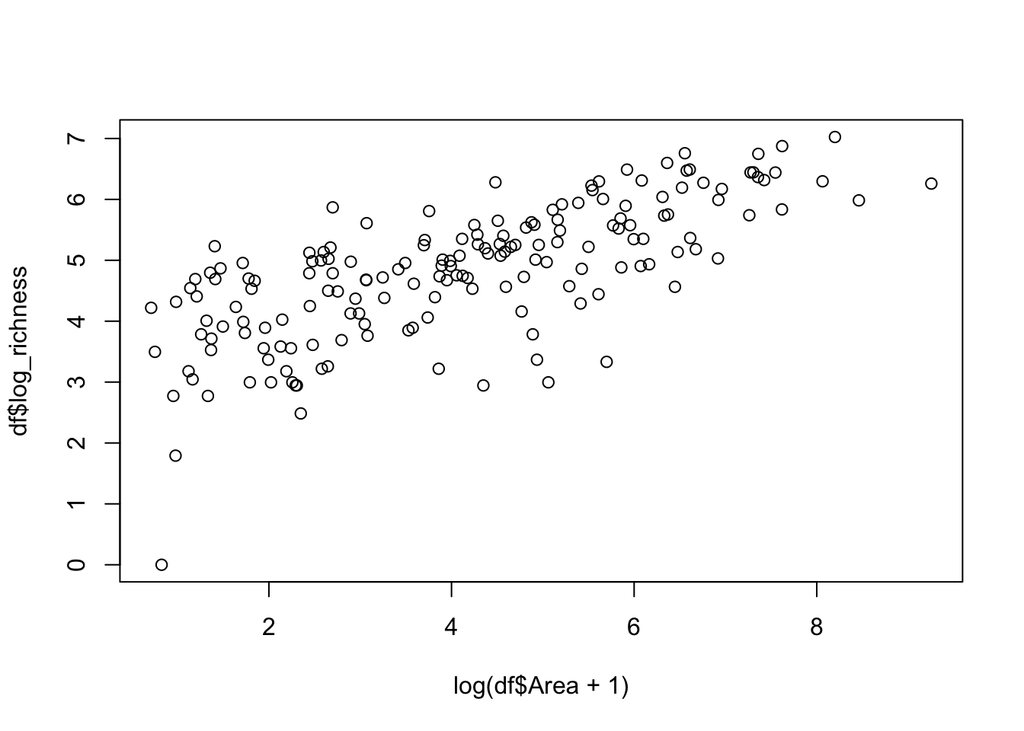

```r
plot(log(df$Area + 1), df$log_richness) # looks good, clear positive relationship
```

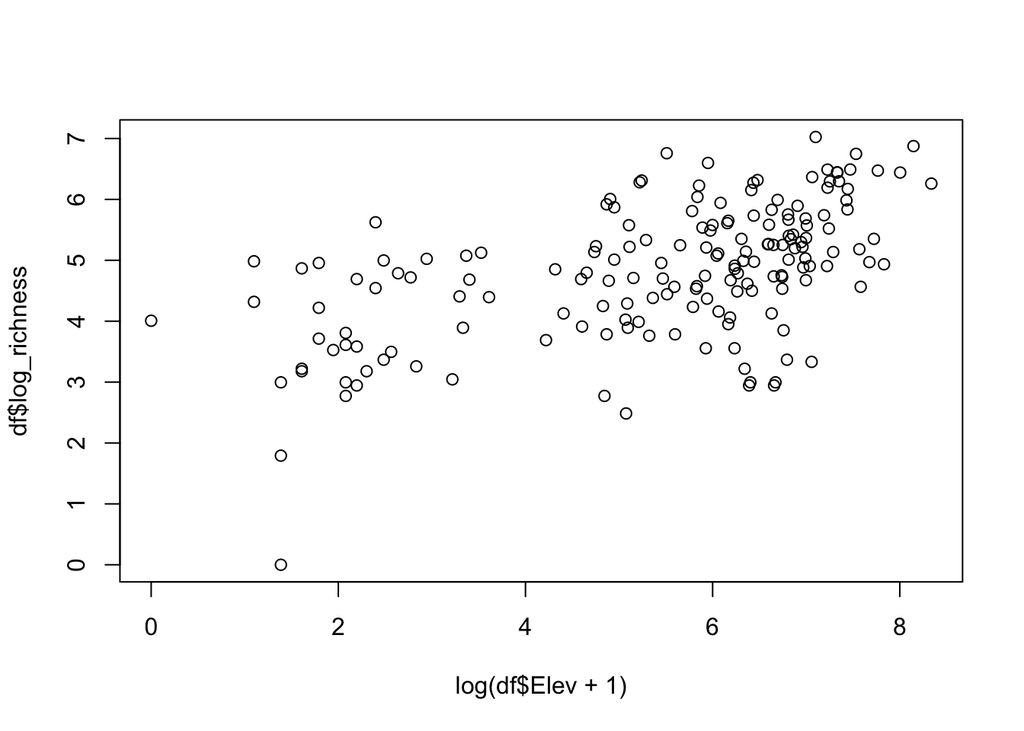

```r
plot(log(df$Elev + 1), df$log_richness) # looks good, clear positive relationship
```

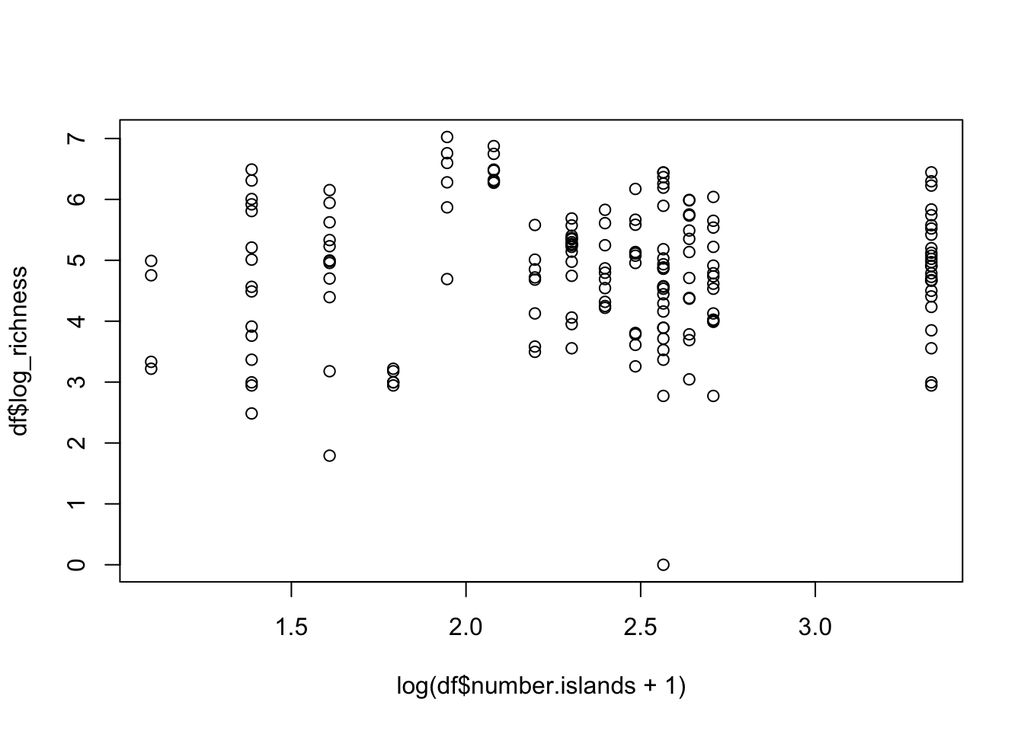

```r
plot(log(df$number.islands + 1), df$log_richness) # more uniform, no clear relationship
```

predictor variable transformation in df

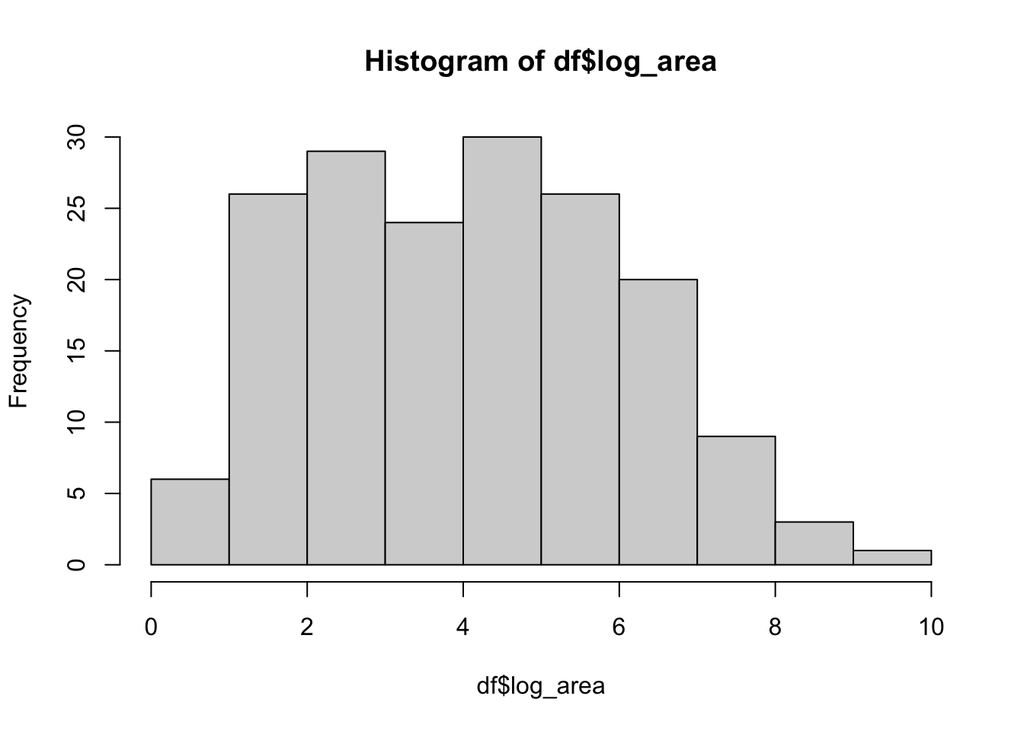

```r
df$log_area <- log(df$Area + 1)
df$log_elev <- log(df$Elev + 1)
df$log_islands <- log(df$number.islands + 1)

hist(df$log_area) # very normal dist.
```

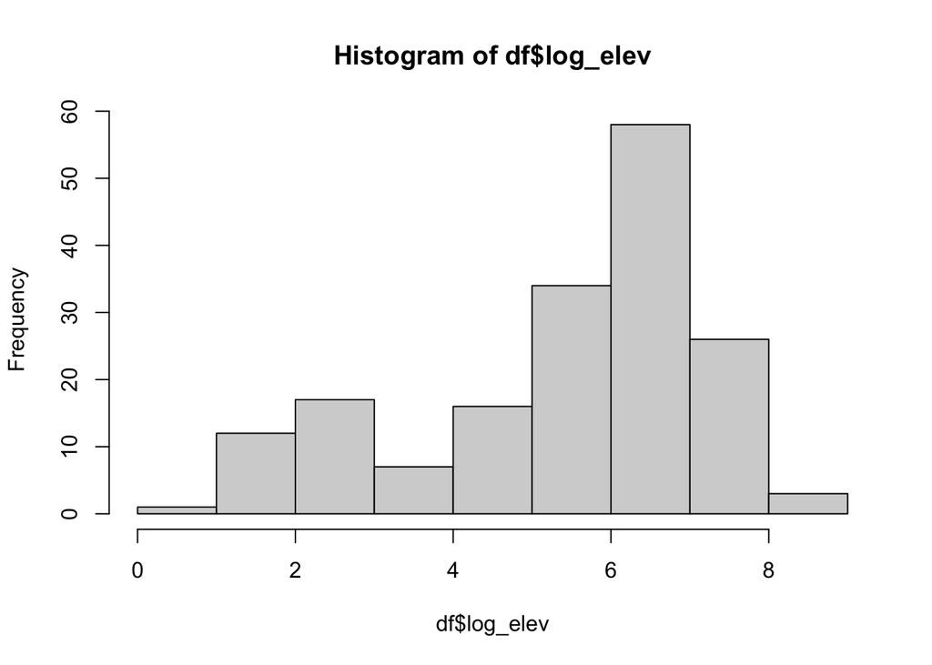

```r
hist(df$log_elev) # not perfect normal dist. but prob okay?
```

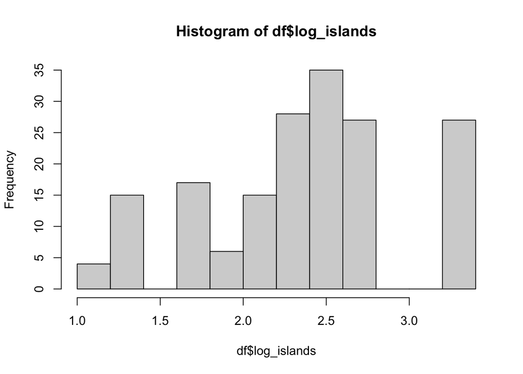

```r
hist(df$log_islands) # now close to normal dist.
```

Construct mixed model(s) that test the roles of the six predictors in explaining species richness. Plot fitted (fixed) effects as well as random effect estimates, plus model diagnostics.

```r
mod_rich_full <- lmer(log_richness ~ log_area + log_elev + log_islands +
                        distance + age + Temp +
                        (1|Archipelago), data = df)
summary(mod_rich_full)
```

```
## Linear mixed model fit by REML. t-tests use Satterthwaite's method [
## lmerModLmerTest]
## Formula: log_richness ~ log_area + log_elev + log_islands + distance +
##     age + Temp + (1 | Archipelago)
##    Data: df
##
## REML criterion at convergence: 354.2
##
## Scaled residuals:
##     Min      1Q  Median      3Q     Max
## -5.6428 -0.5238  0.0832  0.5057  2.1026
##
## Random effects:
##  Groups      Name        Variance Std.Dev.
##  Archipelago (Intercept) 0.4982   0.7058
##  Residual                0.2592   0.5091
## Number of obs: 174, groups:  Archipelago, 23
##
## Fixed effects:
##               Estimate Std. Error         df t value Pr(>|t|)
## (Intercept)  1.395e+00  6.847e-01  2.219e+01   2.038  0.05367 .
## log_area     3.579e-01  3.455e-02  1.577e+02  10.360  < 2e-16 ***
## log_elev     8.644e-02  4.027e-02  1.607e+02   2.146  0.03334 *
## log_islands  5.306e-02  2.829e-01  1.571e+01   0.188  0.85361
## distance    -1.937e-04  9.759e-05  1.605e+01  -1.985  0.06450 .
## age          6.326e-03  6.766e-03  1.601e+01   0.935  0.36368
## Temp         7.665e-02  2.179e-02  2.284e+01   3.518  0.00186 **
## ---
## Signif. codes:  0 '***' 0.001 '**' 0.01 '*' 0.05 '.' 0.1 ' ' 1
##
## Correlation of Fixed Effects:
##             (Intr) log_ar log_lv lg_sln distnc age
## log_area     0.129
## log_elev    -0.291 -0.740
## log_islands -0.647  0.012 -0.047
## distance    -0.018  0.072 -0.004 -0.189
## age         -0.009 -0.023  0.080 -0.334  0.399
## Temp        -0.525 -0.192  0.231 -0.063 -0.308 -0.106
## fit warnings:
## Some predictor variables are on very different scales: consider rescaling
```

fixed effects

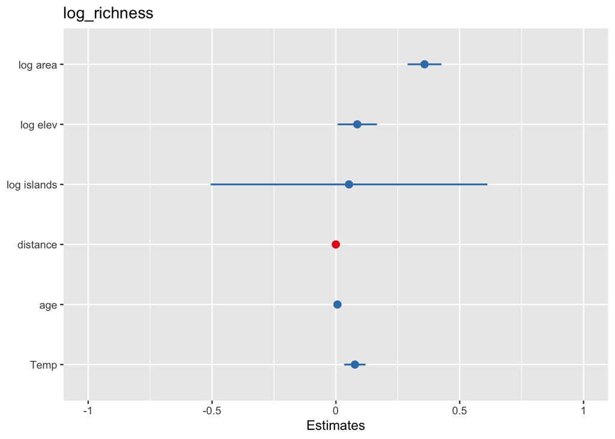

```r
plot_model(mod_rich_full, type = 'est')
```

```r
# estimate for log area, log elev, temp doesn't overlap 0
```

plot random effects

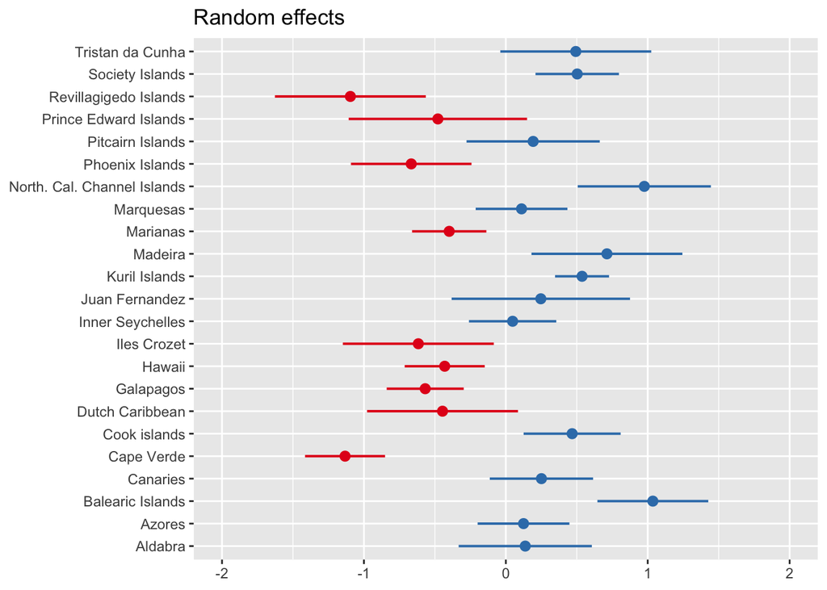

```r
plot_model(mod_rich_full, type = 're')
```

model diagnostics

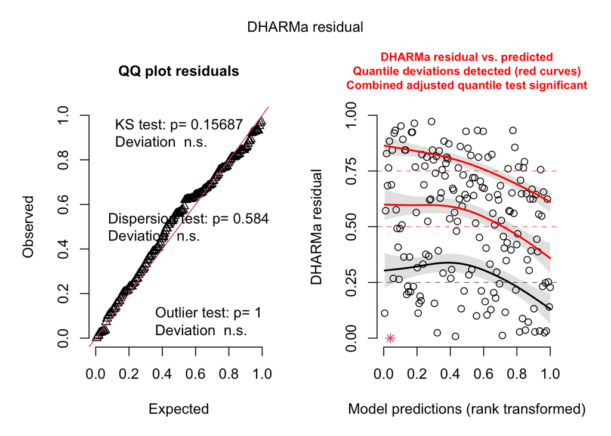

```r
sim_res <- simulateResiduals(mod_rich_full)
plot(sim_res)
```

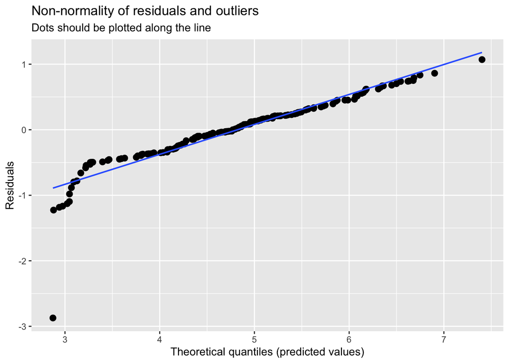

```
##
## [[2]]
## [[2]]$Archipelago
```

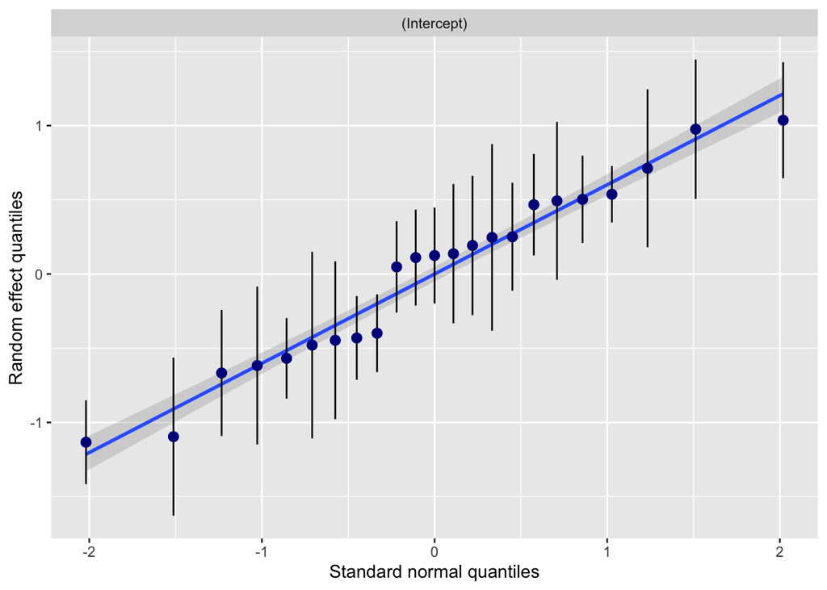

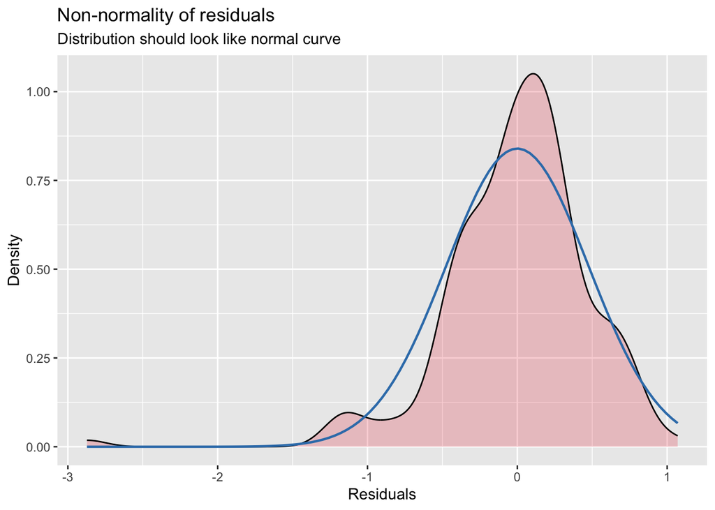

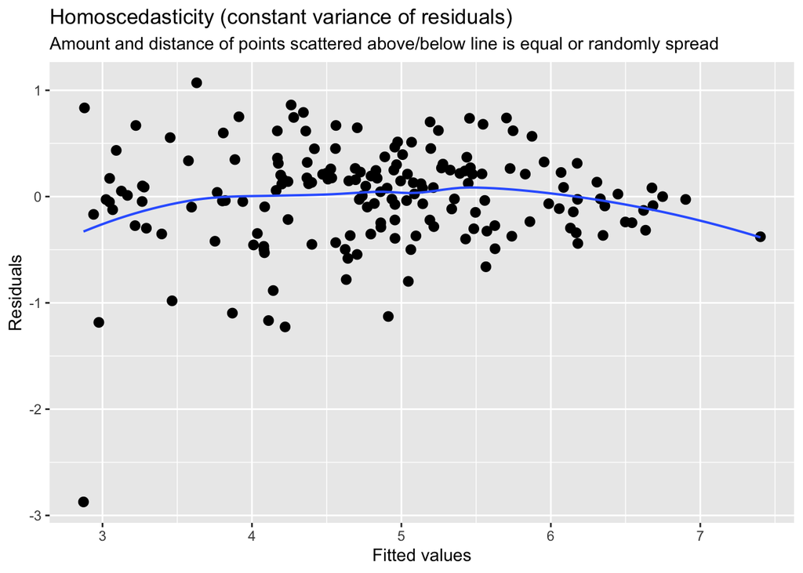

```r
# observed vs. expected plot looks good
# quantile deviations detected, adjusted quantile test significant

plot_model(mod_rich_full, type = 'diag')
```